# Mortality modelling and forecasting

## Introduction

- The life table plays an important role in actuarial sciences.
- It is one of the oldest topics in the field of statistics.
- Important in any area where birth, death or illness may happen.
- Oldest documented life table is Halley’s in 1693.
- It is not limited to human beings.

## Halley’s life table (1693)

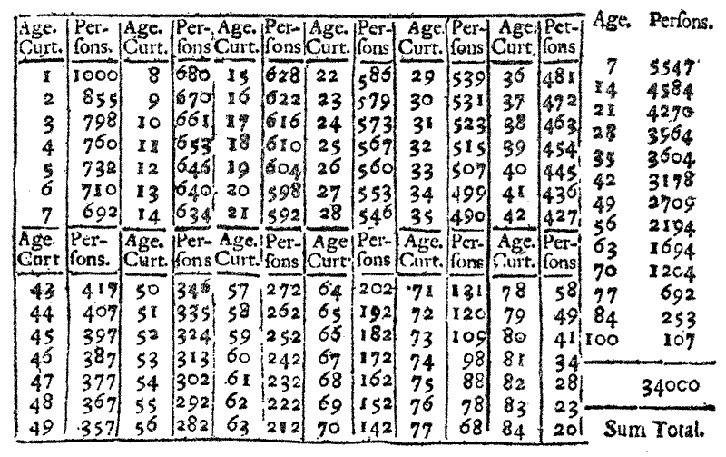

## Types of life tables

- Cohort (dynamic, generational): Records the actual mortality within a group of individuals over a periode of time starting from birth to last death in the group.
- Period (static, current): Considers the mortality of an entire population at a specific point of time.

## Cohort life table

- Suppose we can follow a group, e.g 100.000, of people from a certain group (Female/Male, Non-Smoker/Smoker …) born on the same day, then we can record, at each birthday, the number of group members alive and the number of those dying within the next year.
- Then the ratio of these two quantities gives us the probability of dying at age x.
- In practice this is difficult (even impossible) to do.

## Period life table

- Instead period life tables are much more commonly used.
- These tables are constructed based on an evaluation of the mortality experience of persons from all ages in a short period of time (typically from 1 to 5 years).
- This evaluation can be based on census information provided at regular intervals.

## Modern life table

```r
library(demography)
france<-hmd.mx("FRATNP","aymane10@hotmail.com","STK4500","FRATNP")

lt <- lifetable(france,type="period",years=1950)


lt
```

```
## Period lifetable for FRATNP : female
##
## Year: 1950
##         mx     qx     lx     dx     Lx      Tx      ex
## 0   0.0462 0.0445 1.0000 0.0445 0.9636 69.1879 69.1879
## 1   0.0047 0.0047 0.9555 0.0045 0.9532 68.2243 71.4046
## 2   0.0017 0.0017 0.9510 0.0016 0.9502 67.2711 70.7391
## 3   0.0012 0.0012 0.9494 0.0011 0.9488 66.3209 69.8579
## 4   0.0009 0.0009 0.9482 0.0008 0.9478 65.3721 68.9398
## 5   0.0007 0.0007 0.9474 0.0007 0.9471 64.4243 68.0001
## 6   0.0007 0.0007 0.9467 0.0007 0.9464 63.4772 67.0496
## 7   0.0005 0.0005 0.9461 0.0004 0.9458 62.5308 66.0965
## 8   0.0005 0.0005 0.9456 0.0005 0.9454 61.5850 65.1272
## 9   0.0004 0.0004 0.9451 0.0004 0.9449 60.6396 64.1591
## 10  0.0006 0.0006 0.9448 0.0005 0.9445 59.6947 63.1856
```

[output cut: 90 more lines]

## Columns of a life table

- lx: The number of persons alive at age x.
- dx: The number of persons dead in the interval (x, x+1).
- Lx: The total number of person-years lived in the interval (x, x+1).
- qx: Probability of dying at age x.
- mx: Mortality rate at age x. mx = dx/Lx.
- Tx: Total number of person-years lived by the group from age x til $\omega$, where $\omega$ is the ultimate age.
- ex: The residual life expectancy of persons alive at age x.

## Construction of a life table (Period)

- q(x) (or m(x)) from census data.
- q(x) = 1 - exp(-m(x))
- l(0) = 100.000
- d(x) = l(x)*q(x)
- l(x+1) = l(x) - d(x)
- L(x) = l(x) + a(x)*d(x) (usually a(x)=0.5 except at extreme ages).
- T(x) = Sum from age x to $\omega$ of the L(x) column.
- e(x) = T(x)/l(x)

## The force of mortality $\mu_{x,t}$

- Let $D_{x,t}$ denote the number of deaths of people aged x in year t.
- Let $E_{x,t}$ denote the exposure of age x in year t. This is just L(x) in year t.

Then we can define the force of mortality $\mu_{x,t}$ as:

$\mu_{x,t} = D_{x,t}/E_{x,t}$

## The force of mortality $\mu_{x,t}$

Take for example the data from HMD of “France (Total Population)”, then $\mu_{x,t}$ can be calculated as follows:

```r
country <- "FRATNP"
username <-"aymane10@hotmail.com"
password <- "STK4500"
path <- paste("http://www.mortality.org/hmd/", country, "/STATS/", "Exposures_1x1.txt", sep = "")
userpwd <- paste(username, ":", password, sep = "")
txt <- RCurl::getURL(path, userpwd = userpwd)
con <- textConnection(txt)
exposures <- try(read.table(con, skip = 2, header = TRUE, na.strings = "."),TRUE)

path <- paste("http://www.mortality.org/hmd/", country, "/STATS/", "Deaths_1x1.txt", sep = "")
userpwd <- paste(username, ":", password, sep = "")
txt <- RCurl::getURL(path, userpwd = userpwd)
con <- textConnection(txt)
deaths <- try(read.table(con, skip = 2, header = TRUE, na.strings = "."),TRUE)

EXPOSURE = exposures
DEATH = deaths

DEATH$Age=as.numeric(as.character(DEATH$Age))
DEATH$Age[is.na(DEATH$Age)]=110
EXPOSURE$Age=as.numeric(as.character(EXPOSURE$Age))
EXPOSURE$Age[is.na(EXPOSURE$Age)]=110
```

```r
Mu<-DEATH[,3:5]/EXPOSURE[,3:5]
head(Mu)
```

```
##       Female       Male      Total
## 1 0.18698611 0.22293069 0.20534411
## 2 0.04670190 0.04666953 0.04668535
## 3 0.03392803 0.03430644 0.03412039
## 4 0.02291217 0.02315458 0.02303538
## 5 0.01599465 0.01607464 0.01603530
## 6 0.01383446 0.01363534 0.01373288
```

## The force of mortality $\mu_{x,t}$

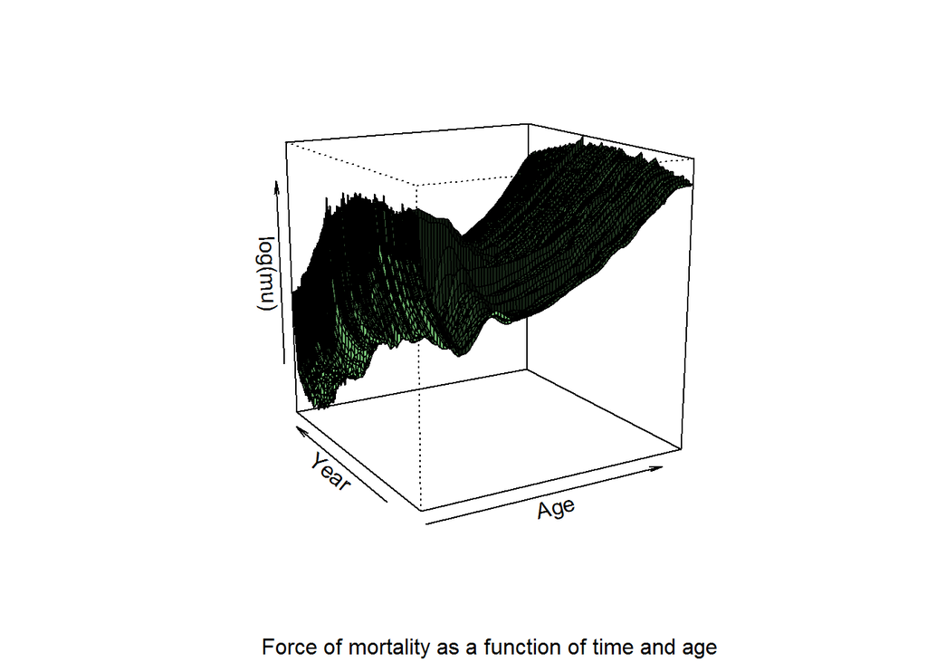

```r
AGE<-as.numeric(DEATH$Age[1:111])
YEAR<-unique(as.numeric(DEATH$Year))
MutM<-matrix(Mu[,2], length(AGE), length(YEAR))
MutF<-matrix(Mu[,1], length(AGE), length(YEAR))

persp(AGE[1:90],YEAR,log(MutM[1:90,]),theta=-30,shade=T,col="light green",xlab="Age",ylab = "Year", zlab ="log(mu)",sub=
                "Force of mortality as a function of time and age", d=3.5)
```

```r
require(rglwidget)
require(rgl)
knitr::knit_hooks$set(webgl = hook_webgl)
persp3d(AGE[1:101],YEAR,log(MutM[1:101,]),theta=-30,shade=T,col="light green")
```

[interactive chart not shown]

## The force of mortality $\mu_{x,t}$ as a function of t (Male)

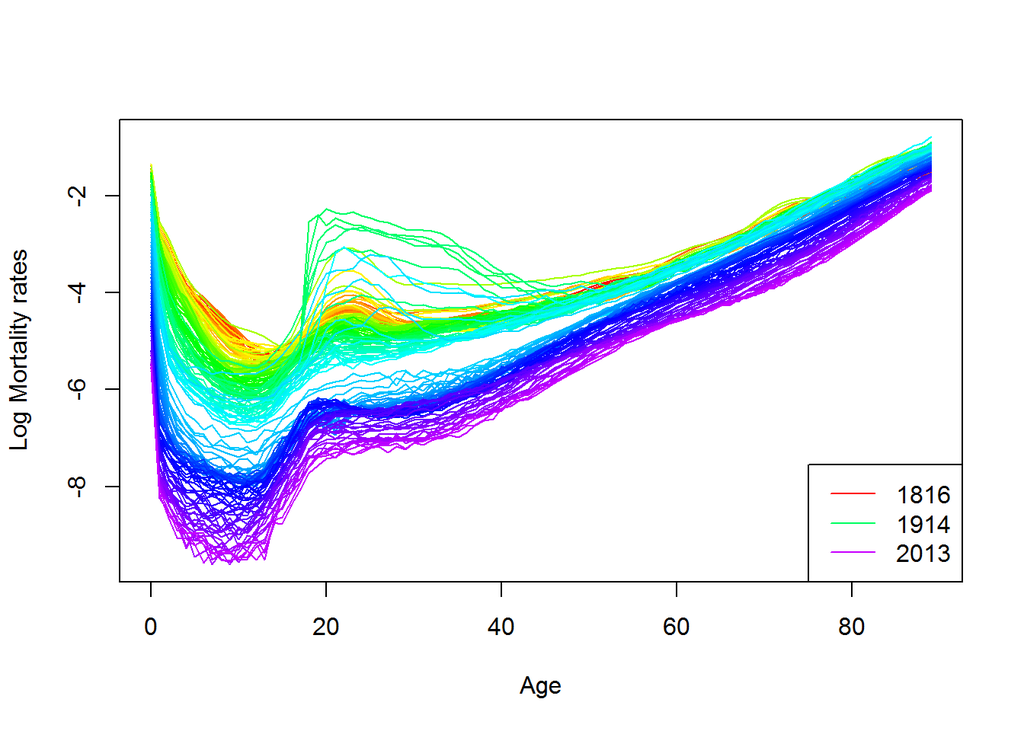

```r
library(rainbow)
rownames(MutM) <- AGE
colnames(MutM) <- YEAR
rownames(MutF) <- AGE
colnames(MutF) <- YEAR
functionalTS <- fts(x = AGE[1:90], y = log(MutM[1:90,]), xname = "Age", yname = "Log Mortality rates")
plot(functionalTS, plot.type = "functions", plotlegend = TRUE, legendpos ="bottomright")
```

## The force of mortality $\mu_{x,t}$ as a function of t (Female)

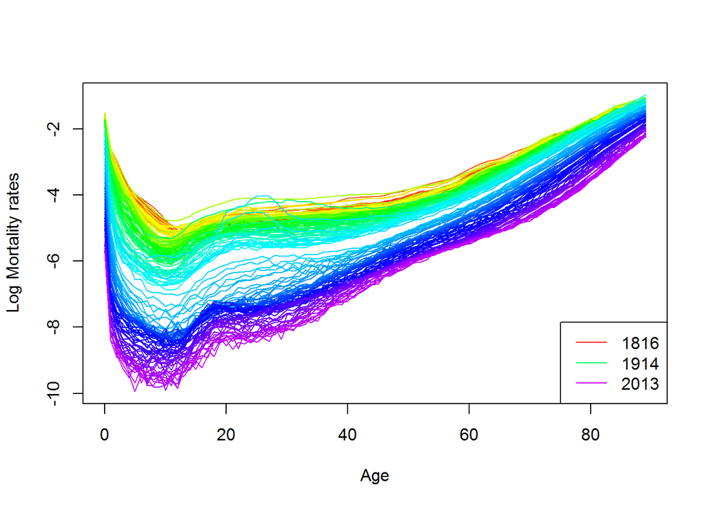

```r
functionalTS <- fts(x = AGE[1:90], y = log(MutF[1:90,]), xname = "Age", yname = "Log Mortality rates")
plot(functionalTS, plot.type = "functions", plotlegend = TRUE, legendpos ="bottomright")
```

## Detecting outliers in the $\mu_{x,t}$ series (Male)

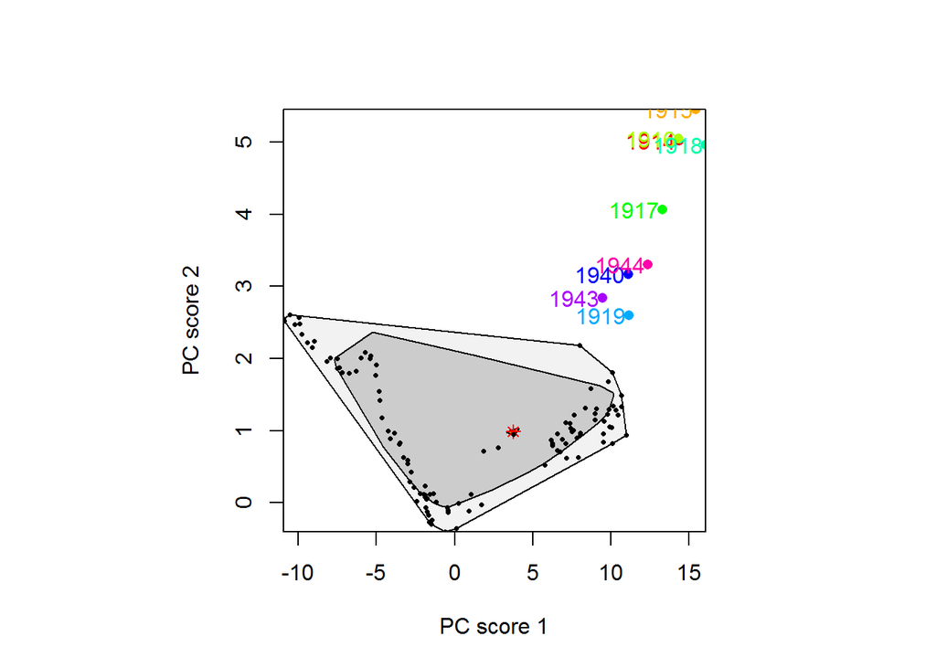

```r
MuM <- fts(x = AGE[1:90], y = log(MutM[1:90,80:198]), xname = "Ages", yname = "Log Mortality rates")


fboxplot(data = MuM, plot.type = "bivariate", type = "bag")
```

## Detecting outliers in the $\mu_{x,t}$ series (Male)

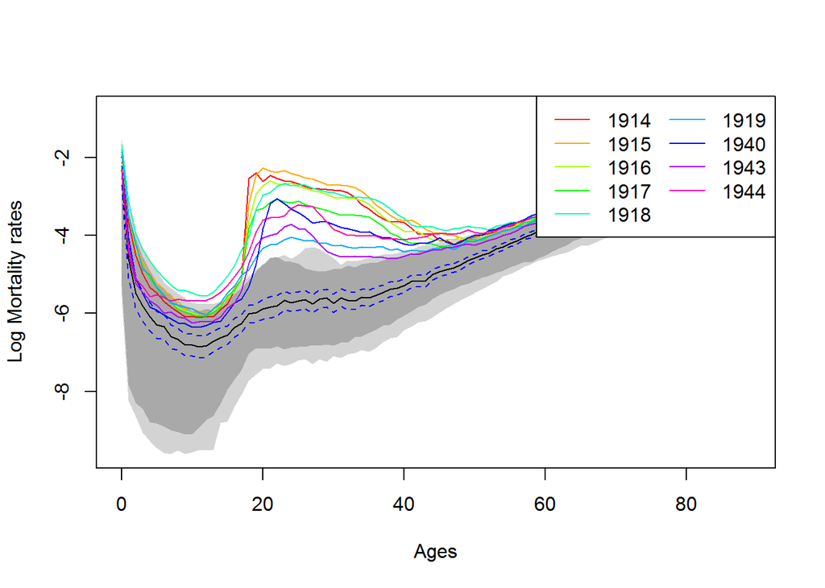

```r
fboxplot(data = MuM, plot.type = "functional", type = "bag")
```

## Detecting outliers in the $\mu_{x,t}$ series (Female)

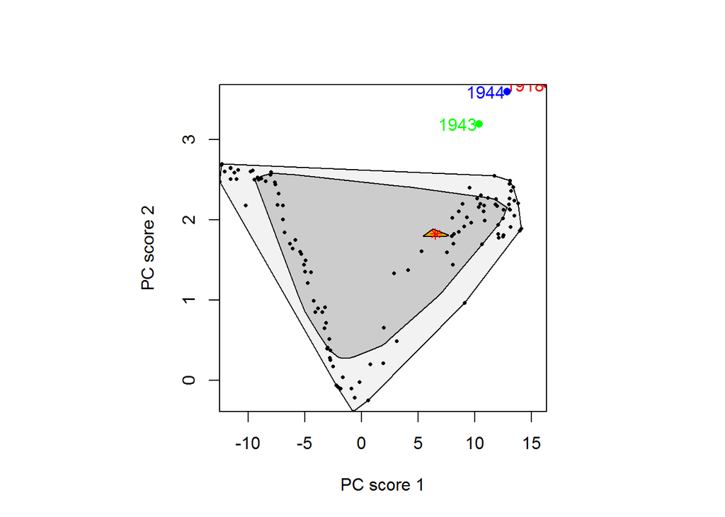

```r
MuF <- fts(x = AGE[1:90], y = log(MutF[1:90,80:198]), xname = "Ages", yname = "Log Mortality rates")


fboxplot(data = MuF, plot.type = "bivariate", type = "bag")
```

## Detecting outliers in the $\mu_{x,t}$ series (Female)

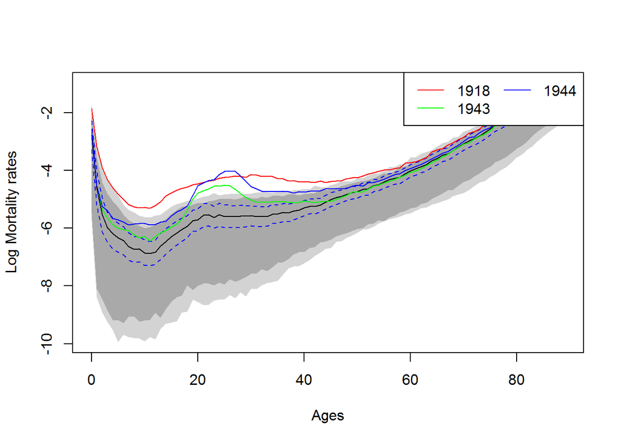

```r
fboxplot(data = MuF, plot.type = "functional", type = "bag")
```

## Comparing $\mu_{x,t}$ for t=1900 and t=1990

```r
year = 1900

D1900 = DEATH[DEATH$Year == year, ]
E1900 = EXPOSURE[EXPOSURE$Year == year, ]
Mu1900 = D1900[, 3:5]/E1900[, 3:5]


year = 1990

D1990 = DEATH[DEATH$Year == year, ]
E1990 = EXPOSURE[EXPOSURE$Year == year, ]
Mu1990 = D1990[, 3:5]/E1990[, 3:5]
```

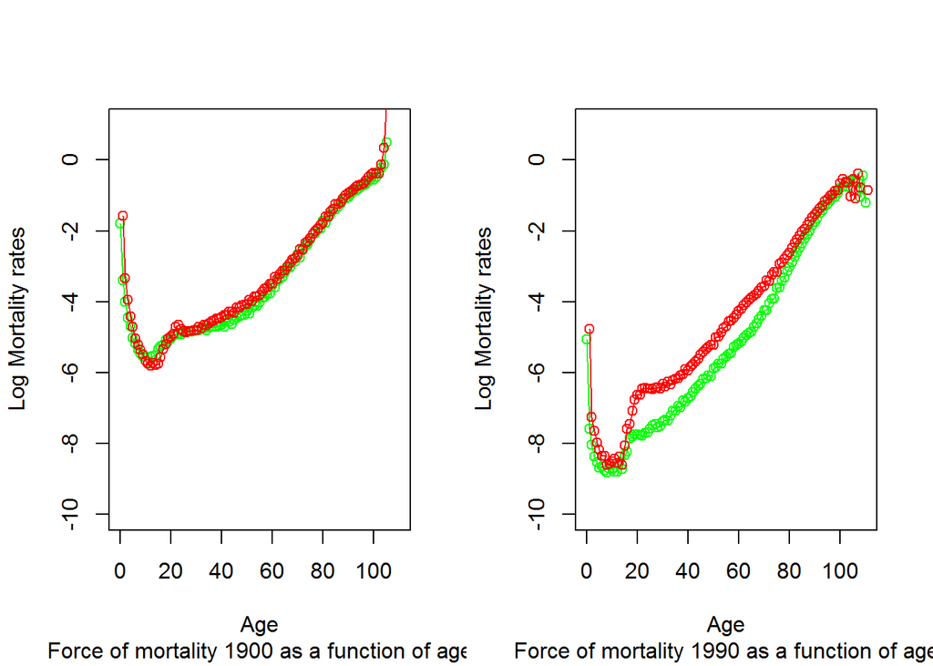

```r
par(mfrow=c(1,2))
plot(0:110,log(Mu1900[,1]), type ="o", col= "green", ylim = c(-10,1), xlab = "Age", ylab =  "Log Mortality rates",
                                                  sub="Force of mortality 1900 as a function of age")
lines(log(Mu1900[,2]), type ="o", col= "red")

plot(0:110,log(Mu1990[,1]), type ="o", col= "green", ylim = c(-10,1), xlab = "Age", ylab =  "Log Mortality rates",
                                                  sub="Force of mortality 1990 as a function of age")
lines(log(Mu1990[,2]), type ="o", col= "red")
```

## Comparing $p_{t}(x,x+1)$ for t=1900 and t=1990

```r
PM1900=PF1900=matrix(0,111,111)
PM1990=PF1990=matrix(0,111,111)


for(x in 0:110){

  PM1900[x+1,1:(111-x)]=exp(-cumsum(Mu1900[(x+1):111,2]))
  PF1900[x+1,1:(111-x)]=exp(-cumsum(Mu1900[(x+1):111,1]))

  PM1990[x+1,1:(111-x)]=exp(-cumsum(Mu1990[(x+1):111,2]))
  PF1990[x+1,1:(111-x)]=exp(-cumsum(Mu1990[(x+1):111,1]))
}
```

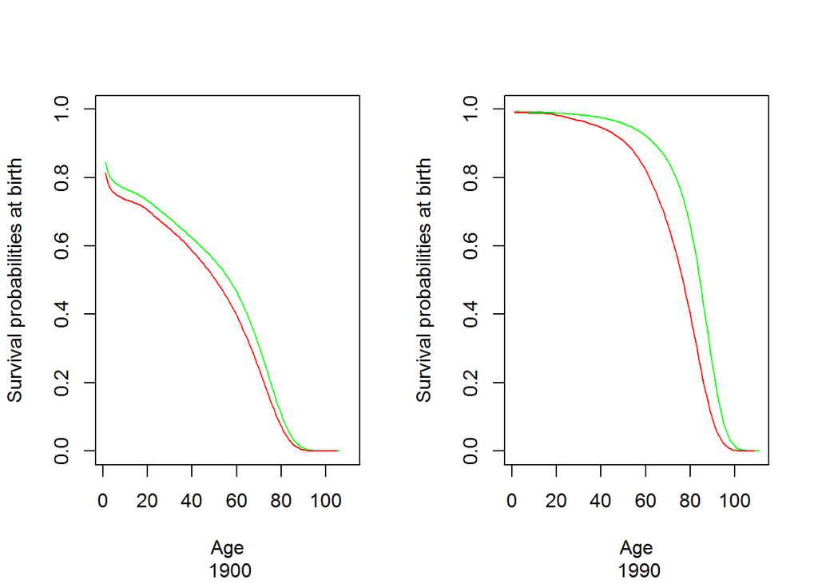

```r
par(mfrow=c(1,2))

plot(1:111,PF1900[1,],ylim=c(0,1),type="l",col="green", xlab = "Age", ylab =  "Survival probabilities at birth",
                                                  sub=" 1900")
lines(PM1900[1,],type="l",col="red")

plot(1:111,PF1990[1,],ylim=c(0,1),type="l",col="green", xlab = "Age", ylab =  "Survival probabilities at birth",
                                                  sub=" 1990")
lines(PM1990[1,],type="l",col="red")
```

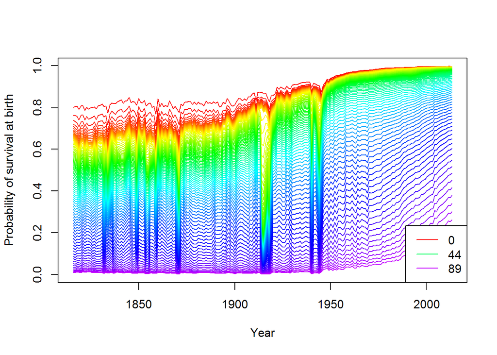

```r
probSurvivalM <- matrix(0, nrow = length(YEAR), ncol = 111)
probSurvivalF <- matrix(0, nrow = length(YEAR), ncol = 111)

for( year in YEAR){

  Dyear=DEATH[DEATH$Year==year,]
  Eyear=EXPOSURE[EXPOSURE$Year==year,]
  Muyear = Dyear[,3:5]/Eyear[,3:5]


  x <- 0

  PMyear=PFyear=matrix(0,1,111)
  PMyear[x+1,1:(111-x)]=exp(-cumsum(Muyear[(x+1):111,2]))
  PFyear[x+1,1:(111-x)]=exp(-cumsum(Muyear[(x+1):111,1]))

  probSurvivalM[year-YEAR[1]+1,] <- PMyear
  probSurvivalF[year-YEAR[1]+1,] <- PFyear

}



rownames(probSurvivalM) <- YEAR
colnames(probSurvivalM) <- AGE

#dim(probSurvival)
#head(probSurvival)
functionalTSM <- fts(x = YEAR, y = (probSurvivalM[,1:90]), xname = "Year", yname = "Probability of survival at birth")
plot(functionalTSM, plot.type = "functions", plotlegend = TRUE, legendpos ="bottomright")
```

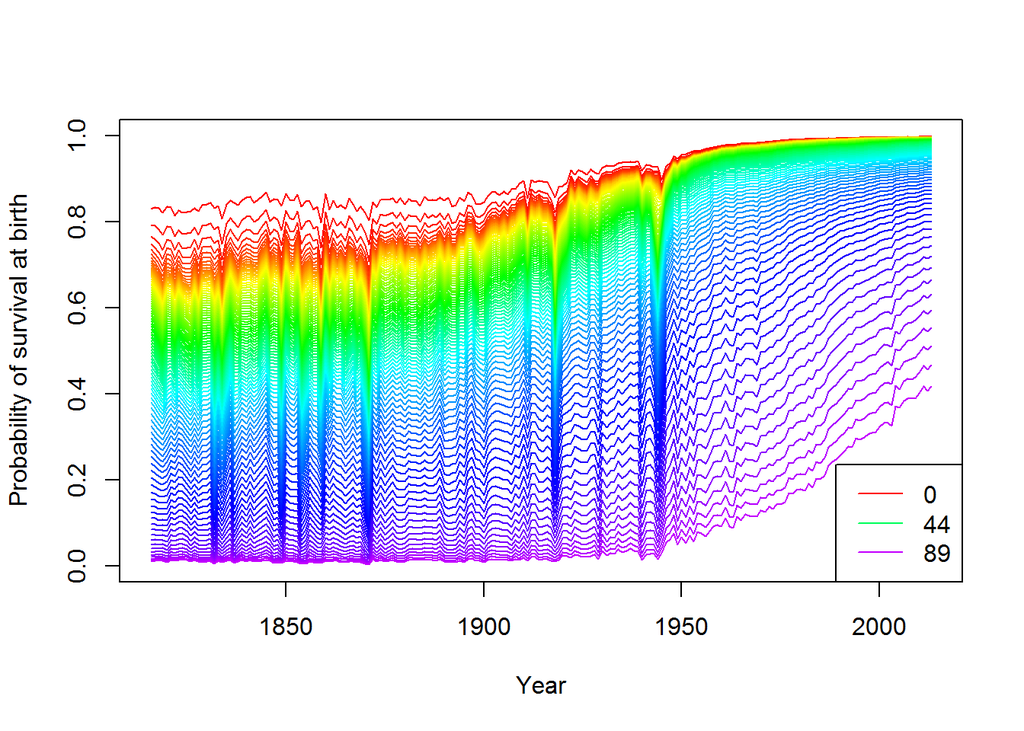

```r
rownames(probSurvivalF) <- YEAR
colnames(probSurvivalF) <- AGE

functionalTSF <- fts(x = YEAR, y = (probSurvivalF[,1:90]), xname = "Year", yname = "Probability of survival at birth")
plot(functionalTSF, plot.type = "functions", plotlegend = TRUE, legendpos ="bottomright")
```

## General remarks on $\mu_{x,t}$

- $x\longmapsto\log(\mu_{x,t})$ has a very similar shape for different $t$’s, and it is (almost) linear from age 30 to 80.
- $t\longmapsto\log(\mu_{x,t})$ has decreasing trend across (almost) all ages.
- In other words, $\log(\mu_{x,t})$ has fixed characteristics for all $t$’s and changing ones through the years.

## The Lee-Carter model (1992)

$\log(\mu_{x,t}) = \alpha_x + \beta_x\kappa_t + \epsilon_{x,t}$

- $\alpha_x$: Age specific component independent of time.
- $\kappa_t$: Time varying parameter indicating the general level of mortality through the years.
- $\beta_x$ : Represents the effect of $\kappa_t$ on each age.
- $\epsilon_{x,t}$ : i.i.d noise.

Due to overparameterization, identification assumptions are imposed e.g:

$\sum_{x}\beta_x = 1,\qquad \sum_{t}\kappa_t = 0$

Estimation is done via Likelihood estimation under certain assumptions.

## Estimation of the Lee-Carter model using $\textbf{demography}$ package

- The demography package has built-in functions for the estimation and forcasting of demographic statistics using the Lee-Carter model.
- In addition, one can use the function $\textbf{hmd.mx}$ to fetch data directly from the $\textit{Human Mortality Database}$.

```r
library(demography)
usa<-hmd.mx("USA","aymane10@hotmail.com","STK4500","USA")

usa.90<-extract.ages(usa,ages = 0:90 )

lc.male<- lca(usa.90, series = "male")
lc.female<- lca(usa.90, series = "female")
```

## Estimates of $\alpha_x$, $\beta_x$ and $\kappa_t$ (male)

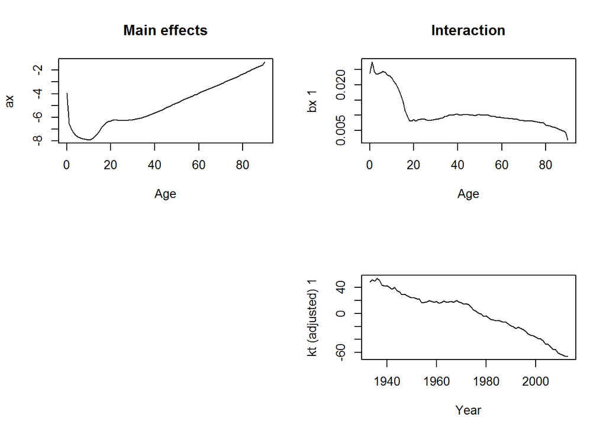

```r
plot(lc.male)
```

## Estimates of $\alpha_x$, $\beta_x$ and $\kappa_t$ (female)

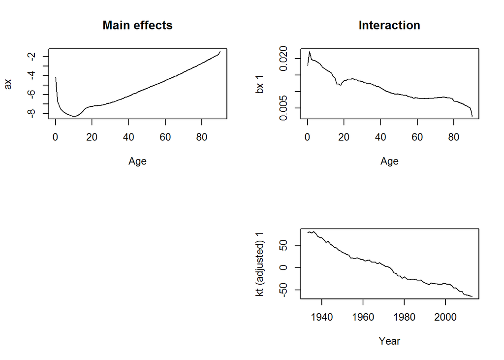

```r
plot(lc.female)
```

## Forcasting in the Lee-Carter model

Forcasting in the Lee-Carter model is easiliy done in the $\textbf{demography}$ package

```r
forecast.lc.male <- forecast(lc.male, h=20)
forecast.lc.female <- forecast(lc.female, h=20)
```

This based on the assumption that $\kappa_t$ is a time series of the form:

$\kappa_t = \theta + \kappa_{t-1} + \xi_t$

and $\xi_t$ are i.i.d normally distributed r.v with mean $0$ and variance $\sigma^2$.

## Forcasting in the Lee-Carter model (Male)

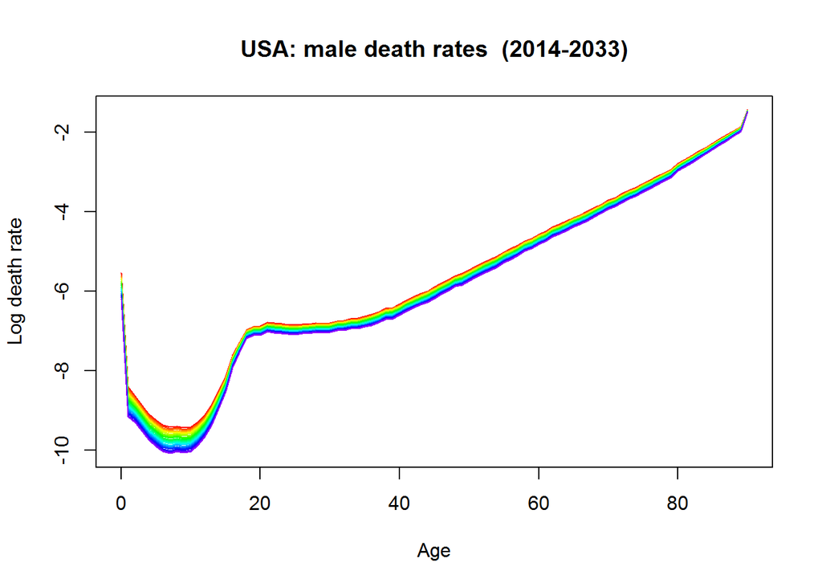

```r
plot(forecast.lc.male)
```

## Forcasting in the Lee-Carter model (Female)

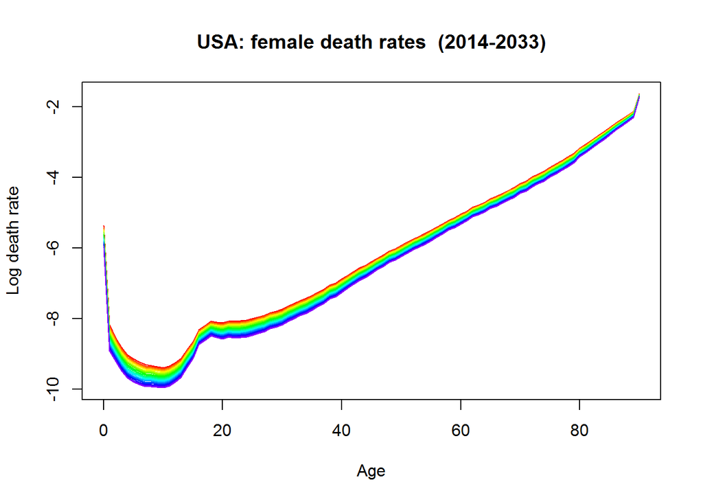

```r
plot(forecast.lc.female)
```

## Estimation and forcastng of $\kappa_t$

```r
kappat <- lc.female$kt
smoothkt <- ets(kappat)
forecastkt <- forecast(smoothkt, h=100)
```

or more concretely

```r
(fittedkt <- auto.arima(kappat))
```

```
## Series: kappat
## ARIMA(0,1,0) with drift
##
## Coefficients:
##         drift
##       -1.7861
## s.e.   0.2766
##
## sigma^2 estimated as 6.121:  log likelihood=-185.99
## AIC=375.97   AICc=376.13   BIC=380.73
```

## Estimation and forecasting of $\kappa_t$ (Female)

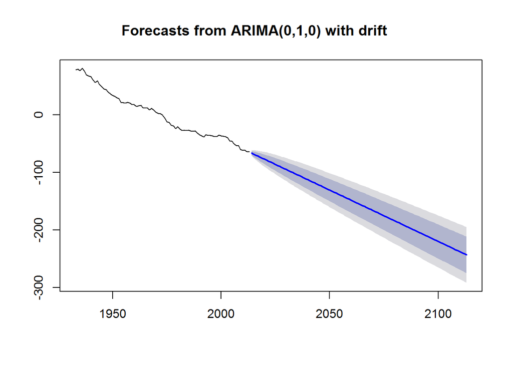

```r
plot(forecast(fittedkt, h=100))
```

## Estimation and forecasting of $\kappa_t$ (Male)

```r
kappat <- lc.male$kt
fittedkt <- auto.arima(kappat)
```

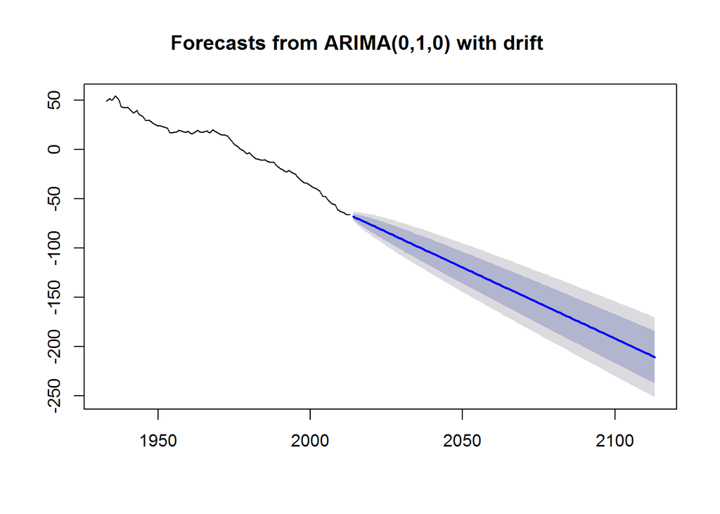

```r
plot(forecast(fittedkt, h=100))
```

## The LifeMetrics functions

- The problem with the $\textbf{demography}$ package is that it implements only the Lee-Carter model.
- Although the Lee-Carter model is widely used in practice, there are other models that have improved the ideas in L-C.
- For example, the Renshaw-Haberman model (2006) adds another component that takes into account the year of birth (i.e cohort effect)

$\log(\mu_{x,t}) = \alpha_x + \beta_x\kappa_t + \delta_x\gamma_{t-x} + \epsilon_{x,t}$

- The LifeMetrics package has several models that are built-in.
- In addition one can simulate different senarios based on the forecasted component.

## LifeMetrics

```r
country <- "USA"
username <-"aymane10@hotmail.com"
password <- "STK4500"
path <- paste("http://www.mortality.org/hmd/", country, "/STATS/", "Exposures_1x1.txt", sep = "")
userpwd <- paste(username, ":", password, sep = "")
txt <- RCurl::getURL(path, userpwd = userpwd)
con <- textConnection(txt)
exposures <- try(read.table(con, skip = 2, header = TRUE, na.strings = "."),TRUE)

path <- paste("http://www.mortality.org/hmd/", country, "/STATS/", "Deaths_1x1.txt", sep = "")
userpwd <- paste(username, ":", password, sep = "")
txt <- RCurl::getURL(path, userpwd = userpwd)
con <- textConnection(txt)
deaths <- try(read.table(con, skip = 2, header = TRUE, na.strings = "."),TRUE)

deaths$Age=as.numeric(as.character(deaths$Age))
deaths$Age[is.na(deaths$Age)]=110
exposures$Age=as.numeric(as.character(exposures$Age))
exposures$Age[is.na(exposures$Age)]=110
```

```r
DEATH_90<- deaths[deaths$Age<90,]
EXPOSURE_90<- exposures[exposures$Age<90,]

Ages <- unique(DEATH_90$Age)
Years <- unique(DEATH_90$Year)

ages <- seq(0,length(Ages)-1)
years <- seq(Years[1],Years[length(Years)])

n <- length(ages)
m <- length(years)
EXPOSUREM_tx <- t(matrix(EXPOSURE_90[,4],n,m))
EXPOSUREF_tx <- t(matrix(EXPOSURE_90[,3],n,m))
DEATHM_tx <- t(matrix(DEATH_90[,4],n,m))
DEATHF_tx <- t(matrix(DEATH_90[,3],n,m))

WeightFun <- matrix(1,m,n)
```

```r
source("C:/Users/Amin/Documents/R/fitModels.r")


LeeCarterM <- fit701(xv=ages,yv=years,
                     etx=EXPOSUREM_tx,dtx=DEATHM_tx,
                     wa=WeightFun)
```

```
## -385163.2 -> -258864.9  ->-246107.4
## -244021.2 -> -243940.9  ->-243737.5
## -243660.3 -> -243647.5  ->-243627.6
## -243616.3 -> -243614.2  ->-243611.4
## -243609.6 -> -243609.3  ->-243608.8
## -243608.5 -> -243608.5  ->-243608.4
## -243608.4 -> -243608.3  ->-243608.3
## -243608.3 -> -243608.3  ->-243608.3
## -243608.3 -> -243608.3  ->-243608.3
## -243608.3 -> -243608.3  ->-243608.3
## -243608.3 -> -243608.3  ->-243608.3
## -243608.3 -> -243608.3  ->-243608.3
```

```r
LeeCarterF <- fit701(xv=ages,yv=years,
                     etx=EXPOSUREF_tx,dtx=DEATHF_tx,
                     wa=WeightFun)
```

```
## -266297.1 -> -155104.8  ->-146414.3
## -134692.9 -> -132618.6  ->-131449.1
## -130165.9 -> -129946  ->-129688
## -129489.1 -> -129461.1  ->-129410.8
## -129377.5 -> -129373.7  ->-129363.9
## -129358 -> -129357.4  ->-129355.5
## -129354.4 -> -129354.3  ->-129353.9
## -129353.7 -> -129353.7  ->-129353.6
## -129353.6 -> -129353.6  ->-129353.6
## -129353.6 -> -129353.6  ->-129353.6
## -129353.6 -> -129353.6  ->-129353.6
## -129353.6 -> -129353.6  ->-129353.6
## -129353.6 -> -129353.6  ->-129353.6
## -129353.6 -> -129353.6  ->-129353.6
```

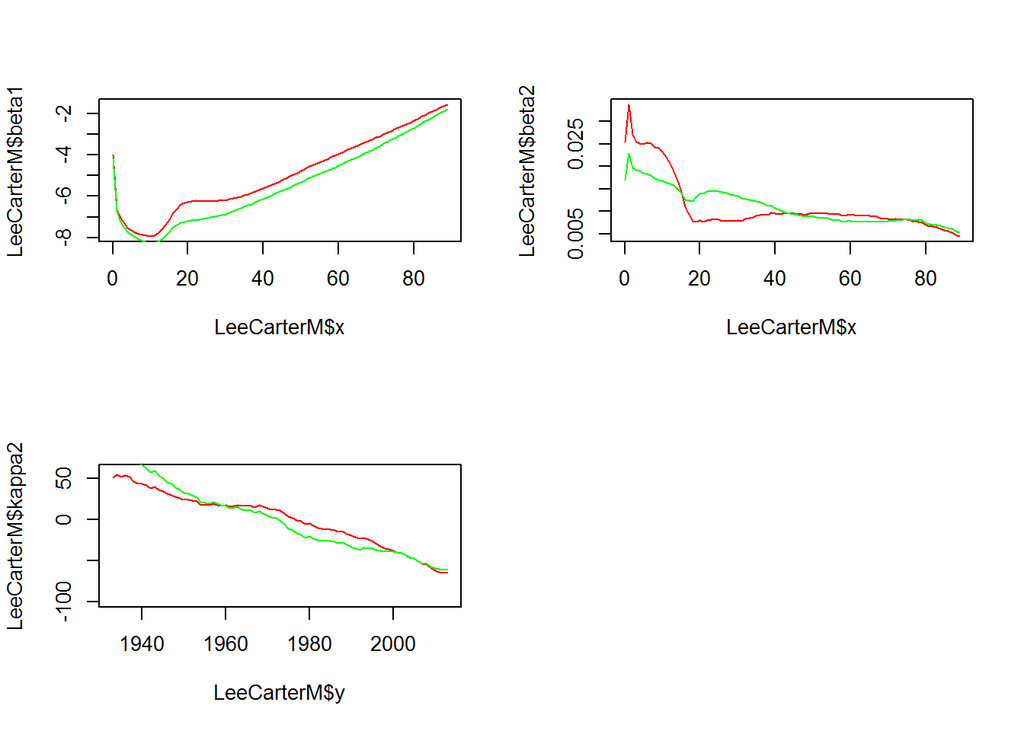

```r
par(mfrow=c(2,2))

plot(LeeCarterM$x,LeeCarterM$beta1,type="l",col="red")
lines(LeeCarterF$x,LeeCarterF$beta1,col="green")

plot(LeeCarterM$x,LeeCarterM$beta2,type="l",col="red")
lines(LeeCarterF$x,LeeCarterF$beta2,col="green")

plot(LeeCarterM$y,LeeCarterM$kappa2,type="l",col="red", ylim = c(-100,60))
lines(LeeCarterF$y,LeeCarterF$kappa2,col="green")
```

## Forecasting with LifeMetrics

```r
source("C:/Users/Amin/Documents/R/simModels.r")


forcastsLC <- sim2001(LeeCarterM$x,LeeCarterM$y,
                      LeeCarterM$beta1,LeeCarterM$beta2,
                      LeeCarterM$kappa2,
                      nsim = 10000,
                      nyears = 60,
                      tmax = 40,
                      x0 = 40)
```

```r
endowment <- array(0,length(forcastsLC$pa[1,]))

for(j in 1:length(endowment)){

  endowment[j] <- (1/(1+0.035)^40)*cumprod(forcastsLC$pa[,j])[length(forcastsLC$pa[,j])]

}

(sort(endowment)[length(endowment)*0.95])

sqrt(var(endowment))
hist(endowment,50)


par(mfrow=c(1,1))

plot(density(endowment))
```

[output not shown]

## Effect of increased longevity on a life insurance annuity

- Using the forcasted time series $\kappa_t$, we can forecast practically any demographical or actuarial quantity we need.
- For example, we can calculate the future survival probabilities by using the estimated $\alpha$ and $\beta$ components in adition to the forecasted time series $\kappa$.

```r
library("demography")
demographicDataM<-hmd.mx("USA","aymane10@hotmail.com","STK4500","USA")
LCM<-lca(demographicDataM, series = "male")




LCMf<-forecast(LCM,h=200)



A <- LCM$ax
B <- LCM$bx
K <- c(LCM$kt,LCM$kt[length(LCM$kt)]+LCMf$kt.f$mean) # Correct the length of k_t
Mu <- matrix(0,length(A),length(K))


for(i in 1:length(A)){

  for(j in 1:length(K)){

    Mu[i,j] <- exp(A[i]+B[i]*K[j])

  }
}

AGE <- seq(0,length(B)-1)
YEARS <- seq(years[1],years[1]+length(K)-1)
#persp(AGE, YEARS, log(Mu), theta=-30,shade=T,col="light green")


t <- 1960
x <- 40
s <- seq(0, 100-x-1)
MuD <- Mu[x+1+s, t+s-years[1]+2]
P_xt <- cumprod(exp(-diag(MuD)))
```

- Or we can calculate the projected PV, at different points in the future, of a deferred temporary life annuity with term $30$ issued for a person aged $40$ and deferred for $30$ years

$\sum_{k = 30}^{30+30-1}\frac{1}{(1+i)^k}p(x,x+k)$

```r
x <- 40
intRate <- 0.035
deferral <- 30
m <-x + deferral

horizon <- 120
valAnnuity <- rep(0,horizon + years[length(years)]-years[1]+1)

for(currYear in years[1]:(horizon + years[length(years)])){
  cohort <- seq(0,100-x-1)
  MuDD <- Mu[x+1+cohort,(cohort+currYear-years[1]+2)]
  P_xt <- cumprod(exp(-diag(MuDD)))
  Durations <- seq(0,deferral)
  val <- ((1/(1+intRate))^(m-x+Durations))*P_xt[m-x+Durations]
  valAnnuity[currYear-years[1]+1] <- sum(val)

}
```

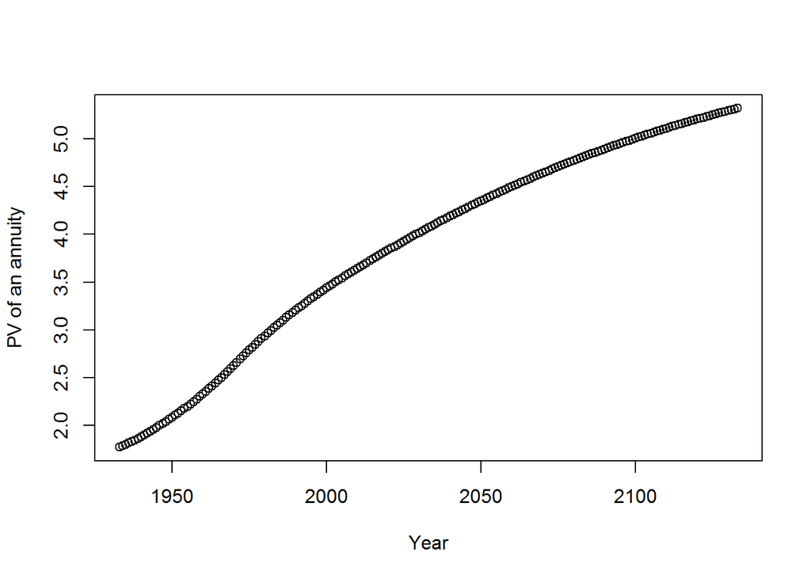

```r
plot(years[1]:(years[length(years)]+horizon),valAnnuity, xlab = "Year", ylab = "PV of an annuity")
```